# Lab 5: Four Models on TNBC and a Clinical Recommendation

Bright Joses

2026-11-27

> **AI use statement.** This submission was produced with substantial help from Claude, an AI assistant made by Anthropic. Claude wrote the R code, ran the analyses and drafted the recommendation, written answers and tables in this file. It was not used only to explain a concept or an error message. All results come from running the code in this file on the supplied TNBC data.

# 0. The task and the Lab 4 pipeline

**Prediction task (as in Lab 4):** will this TNBC patient die of disease? The prediction is made at the tumour board after surgery and tumour profiling, before adjuvant therapy is decided. The positive class is **Died**.

This section rebuilds the Lab 4 pipeline with the same seeds: split first, `mice` fitted on the training rows only (a random forest for tumour stage, which won the masking experiment in Lab 4), then encoding, near-zero-variance filter, training-only scaling, correlation filter, information gain and RFE.

```r
cl <- read.csv("tnbc_clinical.csv", na.strings = c("NA", ""), check.names = FALSE,
               stringsAsFactors = FALSE)
mu <- read.csv("tnbc_mutation.csv", check.names = FALSE)
names(cl)[1] <- "PATIENT_ID"; names(mu)[1] <- "PATIENT_ID"
genes <- setdiff(names(mu), "PATIENT_ID")
dat <- merge(cl, mu, by = "PATIENT_ID", sort = FALSE)
dat$y <- factor(ifelse(dat$VITAL_STATUS == "Died of Disease", "Died", "Living"),
                levels = c("Living", "Died"))

clean_lv <- function(f, signs = FALSE) {
  lv <- levels(f)
  if (signs) lv <- gsub("-", "neg", gsub("\\+", "pos", lv))
  levels(f) <- gsub("[^A-Za-z0-9]+", "_", lv); f
}
typed <- function(d) {
  out <- data.frame(
    AGE_AT_DIAGNOSIS = as.numeric(d$AGE_AT_DIAGNOSIS), NPI = as.numeric(d$NPI),
    TUMOR_SIZE = as.numeric(d$TUMOR_SIZE), MUTATION_COUNT = as.numeric(d$MUTATION_COUNT),
    GRADE = factor(ifelse(is.na(d$GRADE), NA, ifelse(d$GRADE == 3, "3", "1-2")),
                   levels = c("1-2", "3"), ordered = TRUE),
    TUMOR_STAGE = factor(ifelse(is.na(d$TUMOR_STAGE), NA,
                                ifelse(d$TUMOR_STAGE <= 1, "0-1", as.character(d$TUMOR_STAGE))),
                         levels = c("0-1", "2", "3"), ordered = TRUE),
    CELLULARITY = factor(d$CELLULARITY, levels = c("low", "moderate", "high"), ordered = TRUE),
    ER_IHC = factor(d$ER_IHC), LATERALITY = factor(d$LATERALITY),
    BREAST_SURGERY = factor(d$BREAST_SURGERY),
    INFERRED_MENOPAUSAL_STATE = factor(d$INFERRED_MENOPAUSAL_STATE),
    CLAUDIN_SUBTYPE = factor(d$CLAUDIN_SUBTYPE), HER2_SNP6 = factor(d$HER2_SNP6),
    INTCLUST = factor(d$INTCLUST), THREEGENE = factor(d$THREEGENE),
    COHORT = factor(d$COHORT))
  out$INTCLUST  <- clean_lv(out$INTCLUST, signs = TRUE)
  out$THREEGENE <- clean_lv(out$THREEGENE, signs = TRUE)
  out$CLAUDIN_SUBTYPE <- clean_lv(out$CLAUDIN_SUBTYPE)
  out$BREAST_SURGERY  <- clean_lv(out$BREAST_SURGERY)
  out
}
numeric_v <- c("AGE_AT_DIAGNOSIS", "NPI", "TUMOR_SIZE", "MUTATION_COUNT")
ordinal_v <- c("GRADE", "TUMOR_STAGE", "CELLULARITY")
nominal_v <- c("BREAST_SURGERY", "INFERRED_MENOPAUSAL_STATE", "LATERALITY", "ER_IHC",
               "CLAUDIN_SUBTYPE", "HER2_SNP6", "INTCLUST", "THREEGENE")
X <- typed(dat)

set.seed(2026)
s  <- sample.split(dat$y, SplitRatio = 0.7)
tr <- which(s); te <- which(!s)
ytr <- dat$y[tr]; yte <- dat$y[te]
rbind(train = table(ytr), test = table(yte))
```

```
##       Living Died
## train     75   58
## test      32   25
```

```r
st   <- rbind(X[tr, ], X[te, ])
ign  <- c(rep(FALSE, length(tr)), rep(TRUE, length(te)))
meth <- make.method(st); meth[] <- ""
meth[numeric_v] <- "pmm"
meth[c("GRADE", "CELLULARITY")] <- "polr"
meth["TUMOR_STAGE"] <- "rf"
meth[c("ER_IHC", "LATERALITY")] <- "logreg"
meth["THREEGENE"] <- "cart"
meth[colSums(is.na(st)) == 0] <- ""
imp <- suppressWarnings(mice(st, m = 5, maxit = 10, method = meth, ntrees = 100,
                             predictorMatrix = make.predictorMatrix(st),
                             ignore = ign, seed = 1, printFlag = FALSE))
Xc <- mice::complete(imp, 1)
```

```r
make_feat <- function(Xcomp, rows) {
  f <- Xcomp[, c(numeric_v, ordinal_v, nominal_v)]
  for (o in ordinal_v) f[[o]] <- as.integer(f[[o]])
  cbind(f, dat[rows, genes])
}
feat_tr <- make_feat(Xc[seq_along(tr), ], tr)
feat_te <- make_feat(Xc[-seq_along(tr), ], te)
dv  <- dummyVars(~ ., data = feat_tr, fullRank = TRUE)
Etr <- predict(dv, feat_tr); Ete <- predict(dv, feat_te)
colnames(Etr) <- colnames(Ete) <- make.names(colnames(Etr), unique = TRUE)
nz <- nearZeroVar(Etr, saveMetrics = TRUE)
keep_nzv <- rownames(nz)[!nz$nzv]
pp  <- preProcess(Etr[, keep_nzv], method = c("center", "scale"))
Str <- predict(pp, Etr[, keep_nzv]); Ste <- predict(pp, Ete[, keep_nzv])
cm <- cor(Str)
drop_derived <- if (abs(cm["AGE_AT_DIAGNOSIS", "INFERRED_MENOPAUSAL_STATE.pre"]) > 0.8)
  "INFERRED_MENOPAUSAL_STATE.pre" else character(0)
rest <- setdiff(colnames(cm), drop_derived)
corr_drop <- c(drop_derived, findCorrelation(cm[rest, rest], cutoff = 0.8, names = TRUE))
keep_corr <- setdiff(colnames(Str), corr_drop)

H <- function(p) { p <- p[p > 0]; -sum(p * log2(p)) }
ig1 <- function(x, y) {
  if (is.numeric(x) && length(unique(x)) > 2) {
    br <- unique(quantile(x, 0:4 / 4, na.rm = TRUE)); x <- cut(x, br, include.lowest = TRUE)
  }
  tab <- table(x, y); px <- rowSums(tab) / sum(tab)
  H(prop.table(table(y))) - sum(px * apply(tab, 1, function(r) H(r / sum(r))))
}
ig_vec <- function(M, y) sapply(seq_len(ncol(M)), function(j) ig1(M[, j], y))
set.seed(11)
M <- Etr[, keep_corr, drop = FALSE]
ig_real <- ig_vec(M, ytr)
null <- replicate(300, ig_vec(M, sample(ytr)))
ig_pass <- ig_real > apply(null, 1, quantile, probs = 0.95)
ig_keep <- colnames(M)[ig_pass][order(-ig_real[ig_pass])]   # same column order as Lab 4

set.seed(13)
xr <- as.data.frame(Str[, ig_keep, drop = FALSE])
sizes <- sort(unique(pmin(c(2, 3, 4, 5, 6, 8, 10, 12, 15, 20), ncol(xr))))
rfe_fit <- rfe(x = xr, y = ytr, sizes = sizes, ntree = 300,
               rfeControl = rfeControl(functions = rfFuncs, method = "repeatedcv",
                                       number = 5, repeats = 3))
feats <- predictors(rfe_fit)
Atr <- as.data.frame(Str[, feats, drop = FALSE]); Ate <- as.data.frame(Ste[, feats, drop = FALSE])
```

```r
feats
```

```
## [1] "NPI"                       "TUMOR_SIZE"                "BREAST_SURGERY.MASTECTOMY"
## [4] "SHANK2"                    "MAP3K1"
```

Features were chosen on the training rows only. RFE ranks them with random forests, which could give the forest a small advantage in this comparison, and I keep that in mind below.

# 1. Four models on the same training data

All four see the same five features, the same rows and the **same 5-fold, 5-repeat cross-validation folds**. Each is tuned by cross-validated ROC-AUC on the training rows. The test rows are used once, at the end.

```r
set.seed(100)
folds <- createMultiFolds(ytr, k = 5, times = 5)
ctrl <- trainControl(method = "repeatedcv", index = folds, classProbs = TRUE,
                     summaryFunction = twoClassSummary, savePredictions = "final")
set.seed(101)
m_glm <- train(x = Atr, y = ytr, method = "glm", family = binomial(), metric = "ROC", trControl = ctrl)
set.seed(101)
m_tree <- train(x = Atr, y = ytr, method = "rpart", metric = "ROC", trControl = ctrl,
                tuneGrid = data.frame(cp = c(0.001, 0.01, 0.02, 0.03, 0.05, 0.1)))
set.seed(101)
m_rf <- train(x = Atr, y = ytr, method = "rf", metric = "ROC", trControl = ctrl,
              tuneGrid = data.frame(mtry = 1:4), ntree = 500)
set.seed(101)
sig <- as.numeric(sigest(as.matrix(Atr), scaled = FALSE)[2])
m_svm <- train(x = Atr, y = ytr, method = "svmRadial", metric = "ROC", trControl = ctrl,
               tuneGrid = expand.grid(sigma = sig, C = 2^(-2:4)))
models <- list("Logistic regression" = m_glm, "Decision tree" = m_tree,
               "Random forest" = m_rf, "SVM (radial)" = m_svm)
```

```r
lapply(models[-1], function(m) m$bestTune)
```

```
## $`Decision tree`
##     cp
## 3 0.02
##
## $`Random forest`
##   mtry
## 1    1
##
## $`SVM (radial)`
##       sigma  C
## 7 0.1905241 16
```

## Cross-validated performance on the training rows

This is what I use to **choose** a model. The test table below is for **reporting**; choosing the winner from test scores would make its test score optimistic.

```r
cv_tab <- do.call(rbind, lapply(names(models), function(n) {
  r <- models[[n]]$resample
  data.frame(model = n, cv_ROC_AUC = mean(r$ROC), cv_ROC_sd = sd(r$ROC))
}))
cv_tab[, -1] <- round(cv_tab[, -1], 3)
cv_tab[order(-cv_tab$cv_ROC_AUC), ]
```

```
##                 model cv_ROC_AUC cv_ROC_sd
## 3       Random forest      0.738     0.088
## 4        SVM (radial)      0.735     0.085
## 1 Logistic regression      0.697     0.105
## 2       Decision tree      0.669     0.088
```

# 2. Metrics table on the same test data

Every metric is written from the predicted probabilities in base R.

```r
confusion <- function(p, y, thr = 0.5) {
  pred <- p >= thr; pos <- y == "Died"
  c(TP = sum(pred & pos), FP = sum(pred & !pos), TN = sum(!pred & !pos), FN = sum(!pred & pos))
}
safe <- function(a, b) if (b == 0) 0 else a / b
roc_auc <- function(p, y) {                      # P(random positive ranks above random negative)
  r <- rank(p); n1 <- sum(y == "Died"); n0 <- sum(y == "Living")
  (sum(r[y == "Died"]) - n1 * (n1 + 1) / 2) / (n1 * n0)
}
pr_curve <- function(p, y, w_neg = 1) {          # one point per distinct score, ties handled together
  th <- sort(unique(p), decreasing = TRUE)
  pos <- y == "Died"
  do.call(rbind, lapply(th, function(t) {
    tp <- sum(p >= t & pos); fp <- w_neg * sum(p >= t & !pos)
    data.frame(thr = t, recall = tp / sum(pos), precision = tp / (tp + fp),
               fpr = sum(p >= t & !pos) / sum(!pos))
  }))
}
pr_auc <- function(p, y, w_neg = 1) {            # average precision: sum of precision x recall step
  k <- pr_curve(p, y, w_neg)
  sum(diff(c(0, k$recall)) * k$precision)
}
all_metrics <- function(p, y, thr = 0.5) {
  m <- confusion(p, y, thr); TP <- m[["TP"]]; FP <- m[["FP"]]; TN <- m[["TN"]]; FN <- m[["FN"]]
  sens <- safe(TP, TP + FN); spec <- safe(TN, TN + FP)
  c(accuracy = (TP + TN) / sum(m), balanced_accuracy = (sens + spec) / 2,
    sensitivity = sens, specificity = spec, F1 = safe(2 * TP, 2 * TP + FP + FN),
    ROC_AUC = roc_auc(p, y), PR_AUC = pr_auc(p, y))
}
```

```r
probs <- lapply(models, function(m) predict(m, Ate, type = "prob")[, "Died"])
base_p <- rep(mean(ytr == "Died"), length(yte))   # majority-class baseline: always "Living"
probs_all <- c(list("Majority-class baseline" = base_p), probs)
metric_mat <- t(sapply(probs_all, all_metrics, y = yte))
knitr::kable(round(metric_mat, 3), caption = "Test set, threshold 0.5. Positive class = Died.")
```

Test set, threshold 0.5. Positive class = Died.

|  | accuracy | balanced_accuracy | sensitivity | specificity | F1 | ROC_AUC | PR_AUC |
| --- | --- | --- | --- | --- | --- | --- | --- |
| Majority-class baseline | 0.561 | 0.500 | 0.00 | 1.000 | 0.000 | 0.500 | 0.439 |
| Logistic regression | 0.614 | 0.586 | 0.36 | 0.812 | 0.450 | 0.697 | 0.679 |
| Decision tree | 0.649 | 0.617 | 0.36 | 0.875 | 0.474 | 0.592 | 0.580 |
| Random forest | 0.649 | 0.617 | 0.36 | 0.875 | 0.474 | 0.640 | 0.599 |
| SVM (radial) | 0.702 | 0.669 | 0.40 | 0.938 | 0.541 | 0.682 | 0.644 |

```r
conf_mat <- t(sapply(probs_all, confusion, y = yte))
knitr::kable(conf_mat, caption = "Confusion counts on the test set")
```

Confusion counts on the test set

|  | TP | FP | TN | FN |
| --- | --- | --- | --- | --- |
| Majority-class baseline | 0 | 0 | 32 | 25 |
| Logistic regression | 9 | 6 | 26 | 16 |
| Decision tree | 9 | 4 | 28 | 16 |
| Random forest | 9 | 4 | 28 | 16 |
| SVM (radial) | 10 | 2 | 30 | 15 |

```r
prev <- mean(yte == "Died"); n_test <- length(yte)
c(test_patients = n_test, died = sum(yte == "Died"), prevalence = round(prev, 3))
```

```
## test_patients          died    prevalence
##        57.000        25.000         0.439
```

## How uncertain are these numbers?

The test set is small, so I bootstrap the test patients 2,000 times.

```r
set.seed(200)
idx <- replicate(2000, sample(seq_along(yte), replace = TRUE))
idx <- idx[, apply(idx, 2, function(i) length(unique(yte[i])) == 2)]
bs <- lapply(probs, function(p) apply(idx, 2, function(i)
  c(ROC = roc_auc(p[i], yte[i]), PR = pr_auc(p[i], yte[i]))))
ci <- do.call(rbind, lapply(names(bs), function(n) {
  q <- apply(bs[[n]], 1, quantile, c(0.025, 0.975))
  data.frame(model = n, ROC_low = q[1, "ROC"], ROC_high = q[2, "ROC"],
             PR_low = q[1, "PR"], PR_high = q[2, "PR"])
}))
rownames(ci) <- NULL
```

```r
best_cv <- cv_tab$model[which.max(cv_tab$cv_ROC_AUC)]
ci[, -1] <- round(ci[, -1], 3)
knitr::kable(ci, caption = "95% bootstrap intervals on the test set")
```

95% bootstrap intervals on the test set

| model | ROC_low | ROC_high | PR_low | PR_high |
| --- | --- | --- | --- | --- |
| Logistic regression | 0.553 | 0.828 | 0.507 | 0.835 |
| Decision tree | 0.438 | 0.743 | 0.399 | 0.752 |
| Random forest | 0.488 | 0.787 | 0.431 | 0.808 |
| SVM (radial) | 0.534 | 0.823 | 0.477 | 0.840 |

```r
diffs <- do.call(rbind, lapply(setdiff(names(probs), best_cv), function(n) {
  d <- bs[[best_cv]]["ROC", ] - bs[[n]]["ROC", ]
  data.frame(comparison = paste(best_cv, "minus", n), mean_diff_ROC = mean(d),
             low = unname(quantile(d, 0.025)), high = unname(quantile(d, 0.975)))
}))
diffs[, -1] <- round(diffs[, -1], 3)
knitr::kable(diffs, caption = "Paired ROC-AUC differences against the model chosen by cross-validation")
```

Paired ROC-AUC differences against the model chosen by cross-validation

| comparison | mean_diff_ROC | low | high |
| --- | --- | --- | --- |
| Random forest minus Logistic regression | -0.058 | -0.163 | 0.042 |
| Random forest minus Decision tree | 0.048 | -0.086 | 0.201 |
| Random forest minus SVM (radial) | -0.041 | -0.197 | 0.114 |

## ROC and precision-recall curves

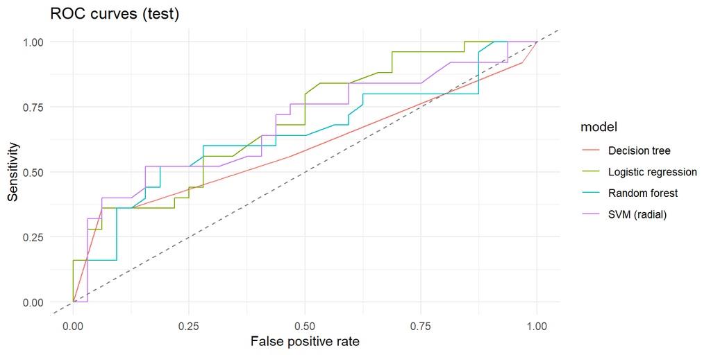

```r
curve_df <- do.call(rbind, lapply(names(probs), function(n) {
  k <- pr_curve(probs[[n]], yte); data.frame(model = n, k)
}))
roc_df <- do.call(rbind, lapply(split(curve_df, curve_df$model), function(d)
  rbind(data.frame(model = d$model[1], fpr = 0, recall = 0), d[, c("model", "fpr", "recall")])))
ggplot(roc_df, aes(fpr, recall, colour = model)) + geom_line() +
  geom_abline(linetype = "dashed", colour = "grey50") +
  labs(title = "ROC curves (test)", x = "False positive rate", y = "Sensitivity") + theme_minimal()
```

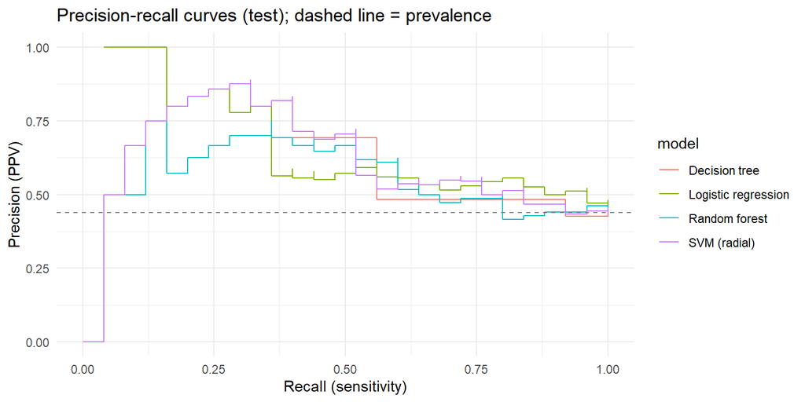

```r
ggplot(curve_df, aes(recall, precision, colour = model)) + geom_step() +
  geom_hline(yintercept = prev, linetype = "dashed", colour = "grey50") +
  labs(title = "Precision-recall curves (test); dashed line = prevalence",
       x = "Recall (sensitivity)", y = "Precision (PPV)") + ylim(0, 1) + theme_minimal()
```

## What happens to ROC-AUC and PR-AUC if the disease is rarer?

I re-weight the test patients who lived so that deaths make up 5% of the population. Sensitivity and specificity do not change; precision does.

```r
w5 <- (sum(yte == "Died") * 0.95 / 0.05) / sum(yte == "Living")   # weight per survivor
rare_tab <- t(sapply(probs, function(p) c(
  ROC_AUC_at_test_prev = roc_auc(p, yte), ROC_AUC_at_5pct = roc_auc(p, yte),
  PR_AUC_at_test_prev = pr_auc(p, yte), PR_AUC_at_5pct = pr_auc(p, yte, w_neg = w5))))
knitr::kable(round(rare_tab, 3))
```

|  | ROC_AUC_at_test_prev | ROC_AUC_at_5pct | PR_AUC_at_test_prev | PR_AUC_at_5pct |
| --- | --- | --- | --- | --- |
| Logistic regression | 0.697 | 0.697 | 0.679 | 0.261 |
| Decision tree | 0.592 | 0.592 | 0.580 | 0.117 |
| Random forest | 0.640 | 0.640 | 0.599 | 0.103 |
| SVM (radial) | 0.682 | 0.682 | 0.644 | 0.139 |

## A threshold chosen for sensitivity (on training data only)

A threshold of 0.5 is arbitrary. For each model I take the **out-of-fold** training predictions and choose the highest threshold that still catches at least 85% of the deaths, then apply it unchanged to the test set.

```r
pick_thr <- function(m, target = 0.85) {
  d <- m$pred
  d <- aggregate(Died ~ rowIndex + obs, data = d, FUN = mean)   # average over repeats
  th <- sort(unique(d$Died), decreasing = TRUE)
  sens <- sapply(th, function(t) mean(d$Died[d$obs == "Died"] >= t))
  th[which(sens >= target)[1]]
}
thr <- sapply(models, pick_thr)
thr_tab <- t(sapply(names(models), function(n) {
  mm <- confusion(probs[[n]], yte, thr[[n]]); a <- all_metrics(probs[[n]], yte, thr[[n]])
  c(threshold = thr[[n]], sensitivity = a[["sensitivity"]], specificity = a[["specificity"]],
    PPV = safe(mm[["TP"]], mm[["TP"]] + mm[["FP"]]), missed_deaths = mm[["FN"]], false_alarms = mm[["FP"]])
}))
knitr::kable(round(thr_tab, 3), caption = "Test results at the sensitivity-targeted thresholds")
```

Test results at the sensitivity-targeted thresholds

|  | threshold | sensitivity | specificity | PPV | missed_deaths | false_alarms |
| --- | --- | --- | --- | --- | --- | --- |
| Logistic regression | 0.274 | 0.96 | 0.188 | 0.480 | 1 | 26 |
| Decision tree | 0.223 | 0.56 | 0.531 | 0.483 | 11 | 15 |
| Random forest | 0.117 | 0.68 | 0.438 | 0.486 | 8 | 18 |
| SVM (radial) | 0.298 | 0.92 | 0.062 | 0.434 | 2 | 30 |

# Interpretability: what do the simple models say?

```r
co <- summary(m_glm$finalModel)$coefficients
or_tab <- data.frame(term = rownames(co), odds_ratio_per_SD = exp(co[, 1]),
                     low = exp(co[, 1] - 1.96 * co[, 2]), high = exp(co[, 1] + 1.96 * co[, 2]),
                     p_value = co[, 4], row.names = NULL)
or_tab[, -1] <- round(or_tab[, -1], 3)
knitr::kable(or_tab, caption = "Logistic regression: odds ratios per 1 SD (binary features are standardised too)")
```

Logistic regression: odds ratios per 1 SD (binary features are standardised too)

| term | odds_ratio_per_SD | low | high | p_value |
| --- | --- | --- | --- | --- |
| (Intercept) | 0.275 | 0.000 | 9.986450e+70 | 0.988 |
| NPI | 1.489 | 0.971 | 2.282000e+00 | 0.068 |
| TUMOR_SIZE | 1.003 | 0.689 | 1.461000e+00 | 0.987 |
| BREAST_SURGERY.MASTECTOMY | 1.544 | 1.042 | 2.289000e+00 | 0.031 |
| SHANK2 | 0.013 | 0.000 | 5.379105e+264 | 0.989 |
| MAP3K1 | 1.824 | 1.050 | 3.171000e+00 | 0.033 |

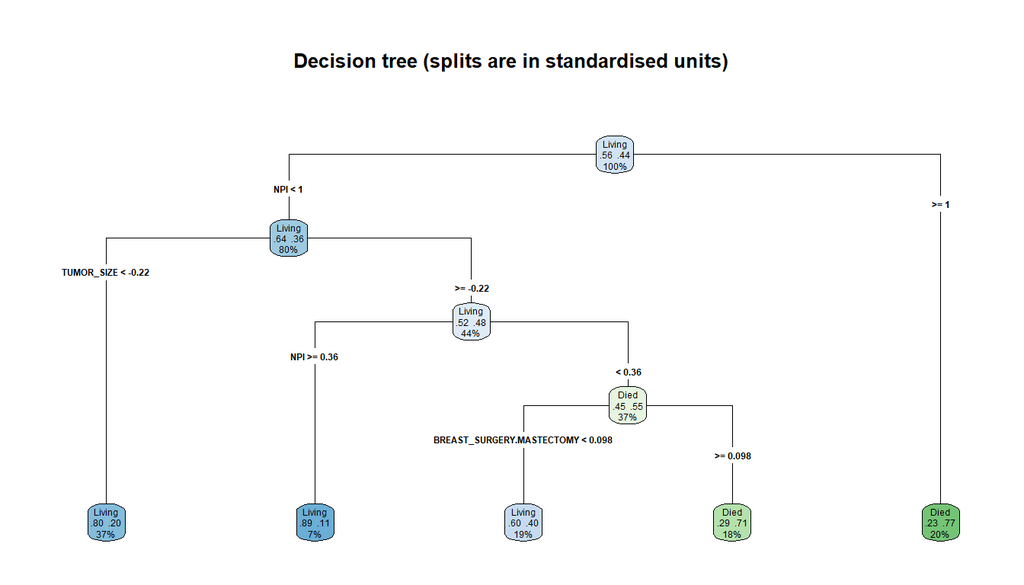

```r
rpart.plot(m_tree$finalModel, type = 4, extra = 104, roundint = FALSE,
           main = "Decision tree (splits are in standardised units)")
```

```r
varImp(m_rf)$importance
```

```
##                             Overall
## NPI                       100.00000
## TUMOR_SIZE                 80.11754
## BREAST_SURGERY.MASTECTOMY  18.48689
## SHANK2                      0.00000
## MAP3K1                      2.58071
```

```r
table(SHANK2_mutated = feat_tr$SHANK2, outcome = ytr)
```

```
##               outcome
## SHANK2_mutated Living Died
##              0     66   58
##              1      9    0
```

The `SHANK2` odds ratio has an impossibly wide interval because of **quasi-separation**: look at the table above. That coefficient should not be read or quoted. `BREAST_SURGERY` (mastectomy) probably stands for tumour extent (bigger or more advanced tumours more often need mastectomy), so it is not a reason to operate differently.

# 3. Recommendation

**Use logistic regression, only to prompt discussion, never to decide treatment.** Cross-validation cannot separate the top models (ROC-AUC 0.74 random forest, 0.73 SVM, 0.70 logistic; gaps under one standard deviation), so I prefer the one a clinician can inspect. Its test ROC-AUC (0.70) and PR-AUC (0.68) were also highest, though intervals overlap.

**Metric:** sensitivity, always beside specificity. At a training-chosen threshold it caught 24 of 25 deaths but flagged 26 of 32 survivors (specificity 0.19, PPV 0.48 against prevalence 0.44). That is little better than calling everyone high risk, so it must not justify withholding or reducing therapy.

**What would change my mind:** a larger external cohort where another model beats it in paired ROC-AUC or PR-AUC with an interval excluding zero; specificity of at least 0.50 at 85% sensitivity; and good calibration. Until then, none of these models is ready for clinical use.

# Written answers

## 1. Why accuracy misleads here

The baseline that predicts “Living” for everyone scores **56.1% accuracy** on the test set (32 of 57) while catching **0 of 25 deaths** (sensitivity 0, balanced accuracy 0.50, F1 0). The highest accuracy of my four models is the SVM (radial)’s 70.2%, which sounds respectable but is only 14 points, about **8 more patients**, above doing nothing. It still misses 15 of the 25 deaths (sensitivity 0.40). Logistic regression is worse on accuracy (61.4%, only 3 patients above the baseline). The tree and the forest have identical confusion matrices at 0.5 and so identical accuracy, yet different ROC-AUC (0.59 against 0.64): accuracy cannot even see that. Accuracy mixes the two kinds of error, weighs them equally, depends on the class mix and on one arbitrary threshold. Balanced accuracy, sensitivity and specificity show what is hidden.

## 2. ROC-AUC against PR-AUC

ROC-AUC compares sensitivity with the false-positive rate. Both are calculated *within* a true class, so ROC-AUC **does not change with prevalence**, and its chance level is always 0.50. PR-AUC uses precision, which depends on how many negatives there are, so its chance level **is the prevalence**. They disagree mainly when the positive class is rare: many false positives barely move the false-positive rate but wreck precision.

On my test set the death rate is 43.9%, close to balanced, and the two **agree on the ranking**: logistic regression (ROC 0.70, PR 0.68), then SVM (0.68, 0.64), random forest (0.64, 0.60) and tree (0.59, 0.58). Remember the baselines: 0.50 for ROC and 0.44 for PR. When I re-weight to 5% prevalence, ROC-AUC is unchanged but PR-AUC falls to 0.26 for logistic regression and 0.10-0.14 for the others, and the tree and forest swap places.

**Which to trust:** the question is about the patients who die, so I give more weight to **PR-AUC read against its prevalence baseline**, and especially if the model were used where deaths are rarer than in this cohort. At this cohort’s prevalence they tell the same story. Neither is precise: with 25 deaths the 95% interval for logistic PR-AUC is 0.507-0.835. The 5% figures rest on very few top-ranked patients, so treat them as an illustration.

## 3. What the two errors mean for a patient

- **False negative:** a patient who will die of the disease is called low risk. The board might lean towards less intensive therapy or less follow-up, and the patient may lose the chance of treatment escalation or a clinical trial. The harm can be irreversible.
- **False positive:** a patient who would survive is called high risk. They may receive more intensive treatment than they need, with real harms (infection from low blood counts, nerve damage, heart toxicity from some drugs), plus anxiety and cost. Some harm is lasting, but it does not by itself leave a cancer under-treated.

**I would report sensitivity first**, at a threshold fixed before looking at the test data, and **never without specificity** next to it, because sensitivity of 100% is free if you call everyone high risk. For a patient the next number is the predictive value *at the local prevalence* (question 4). AUCs are for comparing models; they do not tell a clinician what happens to the person in front of them.

## 4. Positive predictive value at two prevalences

By Bayes’ rule, PPV = (sens x prev) / (sens x prev + (1 - spec) x (1 - prev)).

```r
ppv <- function(se, sp, pr) se * pr / (se * pr + (1 - sp) * (1 - pr))
npv <- function(se, sp, pr) sp * (1 - pr) / (sp * (1 - pr) + (1 - se) * pr)
pts <- list("threshold 0.5" = all_metrics(probs[[lr]], yte, 0.5),
            "sensitivity-targeted threshold" = all_metrics(probs[[lr]], yte, thr[[lr]]))
ppv_tab <- do.call(rbind, lapply(names(pts), function(n) {
  se <- pts[[n]][["sensitivity"]]; sp <- pts[[n]][["specificity"]]
  data.frame(operating_point = n, sensitivity = se, specificity = sp,
             PPV_at_data_prevalence = ppv(se, sp, mean(dat$y == "Died")),
             PPV_at_5pct = ppv(se, sp, 0.05),
             NPV_at_data_prevalence = npv(se, sp, mean(dat$y == "Died")),
             NPV_at_5pct = npv(se, sp, 0.05))
}))
ppv_tab[, -1] <- round(ppv_tab[, -1], 3)
knitr::kable(ppv_tab, caption = "Logistic regression: predictive values (data prevalence = all 190 patients)")
```

Logistic regression: predictive values (data prevalence = all 190 patients)

| operating_point | sensitivity | specificity | PPV_at_data_prevalence | PPV_at_5pct | NPV_at_data_prevalence | NPV_at_5pct |
| --- | --- | --- | --- | --- | --- | --- |
| threshold 0.5 | 0.36 | 0.812 | 0.598 | 0.092 | 0.621 | 0.960 |
| sensitivity-targeted threshold | 0.96 | 0.188 | 0.478 | 0.059 | 0.858 | 0.989 |

The prevalence in my data is 43.7% (83 of 190). At the sensitivity-targeted threshold the PPV is **0.478** there but only **0.059** at 5% prevalence: about **17 patients flagged for each one who would actually die**. At threshold 0.5 the PPV goes from 0.598 to 0.092.

**Effect on the recommendation:** in a low-risk population the model’s “high risk” label would be wrong for the large majority, so it must not be moved to a different setting without recalibrating and re-choosing the threshold. The high NPV at 5% (0.989) is not an achievement: 95% of such people survive anyway. This makes my recommendation narrower: discussion support in a population like this one, and no use at all for screening or low-risk groups. (Death-from-disease prevalence also depends on the length of follow-up, so a number from this cohort does not transfer directly.)

## 5. If the best performer is hardest to explain

Here the cross-validation leader is the **random forest** (0.74), with the SVM close behind; both are hard to explain. Logistic regression is 0.041 lower in cross-validation, less than the fold-to-fold standard deviation (0.10), and on the test set the paired difference (forest minus logistic) is -0.058 with a 95% interval of -0.163 to 0.042, which includes zero. The forest may also have had a small head start, because it helped choose the features.

**To a clinician I would recommend logistic regression** and say this: “Higher nodal-prognostic score (NPI), mastectomy and a `MAP3K1` mutation went with higher odds of death in these patients (odds ratios per standard deviation 1.489, 1.544 and 1.824; the NPI interval includes 1). These are associations, not causes, and the mutation findings are based on very few patients.”

**What I give up:** possibly a small amount of discrimination (up to about 0.04 in cross-validated ROC-AUC, which I cannot show to be real), and any non-linear effects or interactions the forest or SVM might capture. **What I gain:** each input’s effect can be read and challenged, the score can be written down and audited, and an odd coefficient shows up, as the `SHANK2` one did, instead of hiding inside a black box. If a larger external study showed the forest clearly and consistently better, I would change the recommendation and add explanation tools, while telling the clinician those explanations are approximations of the model, not its reasoning.